# R Notebook

Kanayev Azamat Problem 1 Midterm on 27 of April

`r`r fit2=lm(us$rice2009~us$rice2003) summary(fit2)

```
Call:
lm(formula = us$rice2009 ~ us$rice2003)

Residuals:
    Min      1Q  Median      3Q     Max
-23.717  -7.105  -3.602   1.369  50.384

Coefficients:
            Estimate Std. Error t value Pr(>|t|)
(Intercept)  12.5842     2.9442   4.274 8.21e-05 ***
us$rice2003   0.5014     0.1213   4.134  0.00013 ***
---
Signif. codes:  0 â€˜***â€™ 0.001 â€˜**â€™ 0.01 â€˜*â€™ 0.05 â€˜.â€™ 0.1 â€˜ â€™ 1

Residual standard error: 12.93 on 52 degrees of freedom
Multiple R-squared:  0.2474,    Adjusted R-squared:  0.2329
F-statistic: 17.09 on 1 and 52 DF,  p-value: 0.0001302
```

`r`r plot(us$rice2009~us$rice2003) abline(fit2)

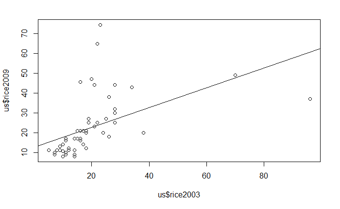

SLR Model y=2.864 + 0.997X beta1 is not equal 0 (p val ~ 0) - we conclude that linear relationship between X and Y

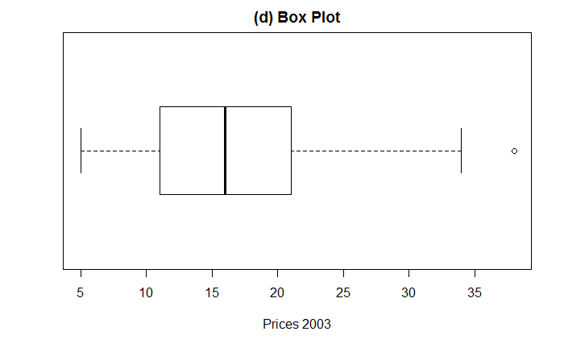

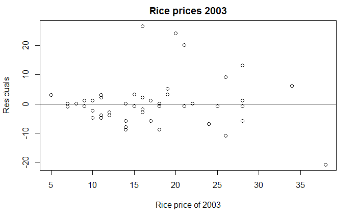

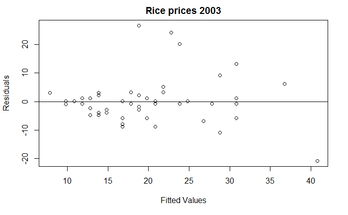

After removing possible outliers we still can see variability (range 17-25)

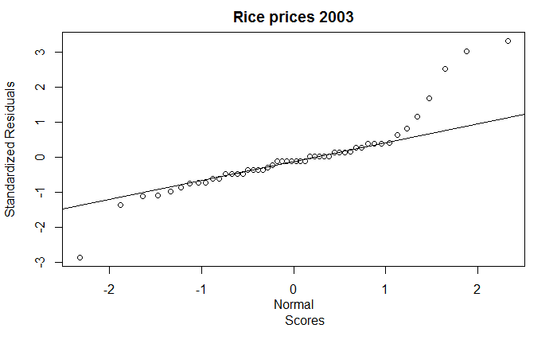

From QQ plot we see deviation from normality of residuals. Residuals are not normal from shapiro test p val<0.05

`r`r shapiro.test(us_stdres)

```
    Shapiro-Wilk normality test

data:  us_stdres
W = 0.85778, p-value = 2.53e-05
```

`r`r library(MASS) boxcox(us$rice2009~us$rice2003)

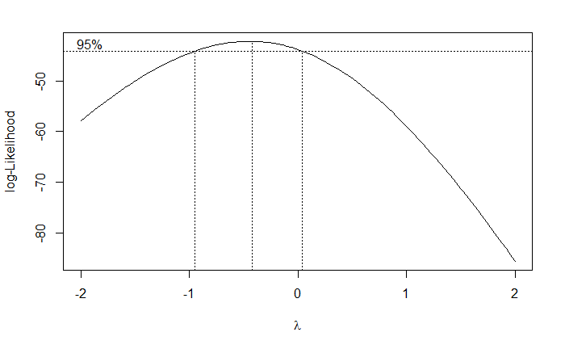

lambda = -0.5 we need transform of Y_i=1/sqrt(Y)

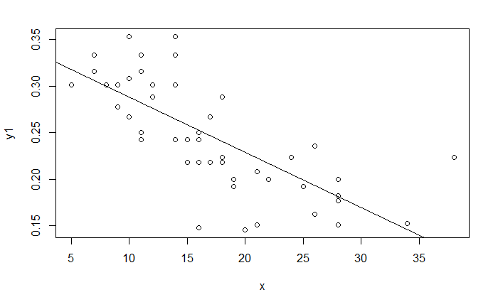

We see the result - variability is decreased. We significantly reduced non-normality of residuals we get. We that residuals now are normal from Shapiro test

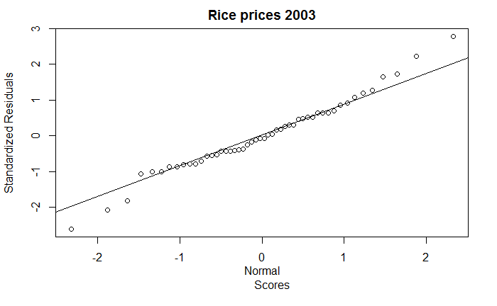

`r`r shapiro.test(us_stdres1)

```
    Shapiro-Wilk normality test

data:  us_stdres1
W = 0.98025, p-value = 0.5627
```